# EDA

2022-06-12

```r
colMapping <- read_tsv("~/Dropbox (Dublin Dental Hosp)/iuna-gui/EA-column-remapping - Sheet1.tsv", show_col_types = FALSE)
```

we keep only the column we need by filtering `skip == FALSE`

```r
colMappingKeep <- colMapping %>% filter(skip == FALSE)
```

```r
sportKeyCodes <- readxl::read_xlsx("~/Dropbox (Dublin Dental Hosp)/iuna-gui/sport_key_codes.xlsx",
                                   col_names = c('participant_id', 'sport'),  n_max = 89)
```

```r
fileName <- "~/Dropbox (Dublin Dental Hosp)/iuna-gui/Elite_athletes_-_latest_version_-_labels_-_2023-10-11-15-00-59.csv"

rawResponses <- read_csv(fileName, locale = locale(decimal_mark = ".", grouping_mark = ","), show_col_types = FALSE, name_repair = "minimal")
```

```r
rawSelection <- rawResponses[, colMappingKeep$kobo_header]
colnames(rawSelection) <- colMappingKeep$column_name
rawSelection <- rawSelection %>% mutate(participant_id=str_to_lower(participant_id))
rawSelection <- rawSelection %>% left_join(sportKeyCodes, c( 'participant_id' = 'participant_id'),
                                           suffix=c("", "_remap"))
```

## Missing sport key code

```r
rawSelection |>
  select(participant_id, sport, sport_details, sport_remap) |>
  filter(is.na(sport_remap))
```

```
## # A tibble: 7 × 4
##   participant_id sport           sport_details sport_remap
##   <chr>          <chr>           <chr>         <chr>
## 1 <NA>           Swimming        <NA>          <NA>
## 2 <NA>           Other           Sailing       <NA>
## 3 <NA>           Swimming        <NA>          <NA>
## 4 <NA>           Gaelic football <NA>          <NA>
## 5 <NA>           Other           Beach tennis  <NA>
## 6 <NA>           Other           Rugby         <NA>
## 7 <NA>           Swimming        <NA>          <NA>
```

```r
#rawSelection %>% filter(!participant_id() %in% #c(1,2,3,4,5,6,7))

rawSelection[-c(1,2,3,4,5,6,7),] %>% head()
```

```
## # A tibble: 6 × 178
##   examiner_id participant_id examiner_reproducibi…¹ assessment_date   age gender
##         <dbl> <chr>          <chr>                  <date>          <dbl> <chr>
## 1           1 aa944ab0       Original               2022-06-07         42 Male
## 2           2 2bb7396e       Original               2022-06-07         27 Female
## 3           1 d2b2feb6       Original               2022-06-07         28 Male
## 4           2 dc69b533       Original               2022-06-07         26 Female
## 5           1 0a05931b       Original               2022-06-07         53 Male
## 6           2 79e09e42       Original               2022-06-07         36 Male
## # ℹ abbreviated name: ¹examiner_reproducibility
## # ℹ 172 more variables: gender_details <lgl>, eircode <chr>,
## #   exact_occupation <chr>, occupation <chr>, years_education <dbl>,
## #   level_education <chr>, ethnicity <chr>, other_ethnicity <chr>,
## #   icdas_score_1_18 <dbl>, icdas_score_1_17 <dbl>, icdas_score_1_16 <dbl>,
## #   icdas_score_1_15 <dbl>, icdas_score_1_14 <dbl>, icdas_score_1_13 <dbl>,
## #   icdas_score_1_12 <dbl>, icdas_score_1_11 <dbl>, icdas_score_2_18 <dbl>, …
```

```r
rawSelection2 <- rawSelection[-c(1,2,3,4,5,6,7),]
```

# pilot subjects removed from orig tsv KBT file

```r
rawSelection2 %>% filter(is.na(sport_remap)) %>% select(participant_id, sport, sport_remap)
```

```
## # A tibble: 0 × 3
## # ℹ 3 variables: participant_id <chr>, sport <chr>, sport_remap <chr>
```

```r
Hmisc::html(Hmisc::describe(rawSelection2))
```

rawSelection2  
178 Variables 88 Observations

examiner_id

| n | missing | distinct | Info | Mean | Gmd |
| --- | --- | --- | --- | --- | --- |
| 88 | 0 | 3 | 0.742 | 97361 | 194719 |

```
 Value            1 8567603
 Frequency       87       1
 Proportion   0.989   0.011
```

For the frequency table, variable is rounded to the nearest 85676.02

participant_id

| n | missing | distinct |
| --- | --- | --- |
| 88 | 0 | 88 |

lowest : 0246610f 04b60e20 087c1d44 0a05931b 0b85a250 , highest: f6531cd1 f81c602e fbdcfa67 fe51e362 fff9d012

examiner_reproducibility

| n | missing | distinct | value |
| --- | --- | --- | --- |
| 88 | 0 | 1 | Original |

```
 Value      Original
 Frequency        88
 Proportion        1
```

assessment_date

```
          n    missing   distinct       Info       Mean        Gmd        .05
         88          0         13      0.987 2022-10-23      127.8 2022-06-07
        .10        .25        .50        .75        .90        .95
 2022-06-14 2022-06-21 2022-11-22 2023-02-03 2023-02-13 2023-04-05
```

```
 Value      2022-06-07 2022-06-13 2022-06-19 2022-06-25 2022-07-04 2022-07-10
 Frequency           7         13          4          6          4          2
 Proportion      0.080      0.148      0.045      0.068      0.045      0.023

 Value      2022-08-27 2022-09-05 2022-11-20 2023-01-31 2023-02-12 2023-04-05
 Frequency           2          5          5         20         12          8
 Proportion      0.023      0.057      0.057      0.227      0.136      0.091
```

For the frequency table, variable is rounded to the nearest 3.02

age

| n | missing | distinct | Info | Mean | Gmd | .05 | .10 | .25 | .50 | .75 | .90 | .95 |
| --- | --- | --- | --- | --- | --- | --- | --- | --- | --- | --- | --- | --- |
| 88 | 0 | 20 | 0.993 | 25.61 | 5.812 | 20.00 | 20.00 | 22.00 | 24.50 | 28.00 | 31.30 | 35.65 |

```
 Value      19.00 19.68 20.70 21.72 22.74 23.76 24.78 25.80 26.82 27.84 28.86 29.88
 Frequency      3    12     5    11     7     6     6     7     6     5     4     5
 Proportion 0.034 0.136 0.057 0.125 0.080 0.068 0.068 0.080 0.068 0.057 0.045 0.057

 Value      30.90 31.92 34.98 36.00 37.70 41.78 42.80 53.00
 Frequency      2     3     1     1     1     1     1     1
 Proportion 0.023 0.034 0.011 0.011 0.011 0.011 0.011 0.011
```

For the frequency table, variable is rounded to the nearest 0.34

gender

| n | missing | distinct |
| --- | --- | --- |
| 88 | 0 | 2 |

```
 Value      Female   Male
 Frequency      33     55
 Proportion  0.375  0.625
```

eircode

| n | missing | distinct |
| --- | --- | --- |
| 88 | 0 | 83 |

lowest : A63t665 A84dd51 A85fd72 A91KD68 A91kx38 , highest: T23Y5N8 T56HE16 V93HX64 X91ea3w X91X76V

exact_occupation

| n | missing | distinct |
| --- | --- | --- |
| 88 | 0 | 37 |

| lowest : | Administration | Athlete | Athlete / student | Athlete and student | Athlete/learning and development pwc |
| --- | --- | --- | --- | --- | --- |
| highest: | Tool maker | Unemployed | Working in restaurant | Works as a shop assistant | Works in a bike rental |

occupation

| n | missing | distinct |
| --- | --- | --- |
| 88 | 0 | 4 |

```
 Value      All other gainfully occupied and unknown
 Frequency                                        69
 Proportion                                    0.784

 Value             Other non manual / skilled manual
 Frequency                                         3
 Proportion                                    0.034

 Value                         Professional managers
 Frequency                                         7
 Proportion                                    0.080

 Value               Semi-skilled / unskilled manual
 Frequency                                         9
 Proportion                                    0.102
```

years_education

| n | missing | distinct | Info | Mean | Gmd | .05 | .10 | .25 | .50 | .75 | .90 | .95 |
| --- | --- | --- | --- | --- | --- | --- | --- | --- | --- | --- | --- | --- |
| 88 | 0 | 11 | 0.977 | 16.55 | 2.45 | 13.35 | 14.00 | 15.00 | 17.00 | 18.00 | 19.00 | 20.00 |

```
 Value         11    12    13    14    15    16    17    18    19    20    21
 Frequency      2     1     2    10    17     9    14    18     7     6     2
 Proportion 0.023 0.011 0.023 0.114 0.193 0.102 0.159 0.205 0.080 0.068 0.023
```

For the frequency table, variable is rounded to the nearest 0.1

level_education

| n | missing | distinct |
| --- | --- | --- |
| 88 | 0 | 5 |

FE College (or equivalent) (17, 0.193), Junior Certificate (3, 0.034), Leaving Certificate (26, 0.295), University postgraduate degree (6, 0.068), University undergraduate degree (36, 0.409)

ethnicity

| n | missing | distinct |
| --- | --- | --- |
| 88 | 0 | 7 |

| lowest : | Any other Asian background | Any other white background-please describe | Black or Black Irish | Irish Traveller | Irish White |
| --- | --- | --- | --- | --- | --- |
| highest: | Black or Black Irish | Irish Traveller | Irish White | Northern Irish/English/Welsh/Scotish | Other, including mixed background-please describe |

other_ethnicity

| n | missing | distinct |
| --- | --- | --- |
| 5 | 83 | 5 |

```
 Value                 American             Armenia       South african
 Frequency                    1                   1                   1
 Proportion                 0.2                 0.2                 0.2

 Value            South African Swiss Irish Italian
 Frequency                    1                   1
 Proportion                 0.2                 0.2
```

icdas_score_1_18

| n | missing | distinct | Info | Mean | Gmd |
| --- | --- | --- | --- | --- | --- |
| 88 | 0 | 6 | 0.677 | 30.23 | 42.44 |

```
 Value       0.00  1.98 95.04 96.03 97.02 99.00
 Frequency     60     1     1     1    10    15
 Proportion 0.682 0.011 0.011 0.011 0.114 0.170
```

For the frequency table, variable is rounded to the nearest 0.99

icdas_score_1_17

| n | missing | distinct | Info | Mean | Gmd |
| --- | --- | --- | --- | --- | --- |
| 88 | 0 | 8 | 0.738 | 2.125 | 3.709 |

```
 Value       0.00  0.97  1.94  2.91  3.88  6.79  7.76 97.00
 Frequency     56     9     1    12     7     1     1     1
 Proportion 0.636 0.102 0.011 0.136 0.080 0.011 0.011 0.011
```

For the frequency table, variable is rounded to the nearest 0.97

icdas_score_1_16

| n | missing | distinct | Info | Mean | Gmd |
| --- | --- | --- | --- | --- | --- |
| 88 | 0 | 6 | 0.898 | 1.852 | 1.981 |

```
 Value       0.00  0.98  1.96  2.94  3.99  7.00
 Frequency     37     7     1    24    17     2
 Proportion 0.420 0.080 0.011 0.273 0.193 0.023
```

For the frequency table, variable is rounded to the nearest 0.07

icdas_score_1_15

| n | missing | distinct | Info | Mean | Gmd |
| --- | --- | --- | --- | --- | --- |
| 88 | 0 | 6 | 0.538 | 7.148 | 13.29 |

```
 Value       0.00  0.98  2.94  3.92 96.04 98.00
 Frequency     68     3     5     6     1     5
 Proportion 0.773 0.034 0.057 0.068 0.011 0.057
```

For the frequency table, variable is rounded to the nearest 0.98

icdas_score_1_14

| n | missing | distinct | Info | Mean | Gmd |
| --- | --- | --- | --- | --- | --- |
| 88 | 0 | 8 | 0.405 | 3.773 | 7.259 |

```
 Value       0.00  0.98  1.96  2.94  3.92  5.88  6.86 98.00
 Frequency     74     1     1     6     1     1     1     3
 Proportion 0.841 0.011 0.011 0.068 0.011 0.011 0.011 0.034
```

For the frequency table, variable is rounded to the nearest 0.98

icdas_score_1_13

| n | missing | distinct | Info | Mean | Gmd |
| --- | --- | --- | --- | --- | --- |
| 88 | 0 | 3 | 0.161 | 0.2045 | 0.3934 |

```
 Value          0     3     6
 Frequency     83     4     1
 Proportion 0.943 0.045 0.011
```

For the frequency table, variable is rounded to the nearest 0.06

icdas_score_1_12

| n | missing | distinct | Info | Mean | Gmd |
| --- | --- | --- | --- | --- | --- |
| 88 | 0 | 3 | 0.329 | 1.455 | 2.823 |

```
 Value       0.00  2.94 98.00
 Frequency     77    10     1
 Proportion 0.875 0.114 0.011
```

For the frequency table, variable is rounded to the nearest 0.98

icdas_score_1_11

| n | missing | distinct | Info | Mean | Gmd |
| --- | --- | --- | --- | --- | --- |
| 88 | 0 | 3 | 0.355 | 0.5455 | 0.9781 |

```
 Value          0     3     6
 Frequency     76     8     4
 Proportion 0.864 0.091 0.045
```

For the frequency table, variable is rounded to the nearest 0.06

icdas_score_2_18

| n | missing | distinct | Info | Mean | Gmd |
| --- | --- | --- | --- | --- | --- |
| 88 | 0 | 5 | 0.595 | 0.7727 | 1.225 |

```
 Value          0     2     3     4     5
 Frequency     65     9     8     4     2
 Proportion 0.739 0.102 0.091 0.045 0.023
```

For the frequency table, variable is rounded to the nearest 0.05

icdas_score_2_17

| n | missing | distinct | Info | Mean | Gmd |
| --- | --- | --- | --- | --- | --- |
| 88 | 0 | 7 | 0.895 | 1.636 | 1.817 |

```
 Value       0.00  0.96  1.98  3.00  3.96  4.98  6.00
 Frequency     39     1    19    17     7     4     1
 Proportion 0.443 0.011 0.216 0.193 0.080 0.045 0.011
```

For the frequency table, variable is rounded to the nearest 0.06

icdas_score_2_16

| n | missing | distinct | Info | Mean | Gmd |
| --- | --- | --- | --- | --- | --- |
| 88 | 0 | 5 | 0.89 | 1.625 | 1.7 |

```
 Value          0     2     3     4     5
 Frequency     36    30     9     9     4
 Proportion 0.409 0.341 0.102 0.102 0.045
```

For the frequency table, variable is rounded to the nearest 0.05

icdas_score_2_15

| n | missing | distinct | Info | Mean | Gmd |
| --- | --- | --- | --- | --- | --- |
| 88 | 0 | 4 | 0.428 | 0.4545 | 0.7868 |

```
 Value          0     2     3     4
 Frequency     73     8     4     3
 Proportion 0.830 0.091 0.045 0.034
```

For the frequency table, variable is rounded to the nearest 0.04

icdas_score_2_14

| n | missing | distinct | Info | Mean | Gmd |
| --- | --- | --- | --- | --- | --- |
| 88 | 0 | 5 | 0.452 | 0.625 | 1.08 |

```
 Value       0.00  1.98  3.00  3.96  6.00
 Frequency     72     5     3     6     2
 Proportion 0.818 0.057 0.034 0.068 0.023
```

For the frequency table, variable is rounded to the nearest 0.06

icdas_score_2_13

| n | missing | distinct | Info | Mean | Gmd |
| --- | --- | --- | --- | --- | --- |
| 88 | 0 | 3 | 0.067 | 0.05682 | 0.1126 |

```
 Value       0.00  1.98  3.00
 Frequency     86     1     1
 Proportion 0.977 0.011 0.011
```

For the frequency table, variable is rounded to the nearest 0.03

icdas_score_2_12

| n | missing | distinct | Info | Mean | Gmd |
| --- | --- | --- | --- | --- | --- |
| 88 | 0 | 4 | 0.249 | 0.25 | 0.4671 |

```
 Value          0     2     3     4
 Frequency     80     4     2     2
 Proportion 0.909 0.045 0.023 0.023
```

For the frequency table, variable is rounded to the nearest 0.04

icdas_score_2_11

| n | missing | distinct | Info | Mean | Gmd |
| --- | --- | --- | --- | --- | --- |
| 88 | 0 | 4 | 0.249 | 0.3182 | 0.5909 |

```
 Value          0     2     3     4
 Frequency     80     1     2     5
 Proportion 0.909 0.011 0.023 0.057
```

For the frequency table, variable is rounded to the nearest 0.04

icdas_score_1_21

| n | missing | distinct | Info | Mean | Gmd |
| --- | --- | --- | --- | --- | --- |
| 88 | 0 | 4 | 0.38 | 1.625 | 3.118 |

```
 Value       0.00  2.94  5.88 98.00
 Frequency     75     9     3     1
 Proportion 0.852 0.102 0.034 0.011
```

For the frequency table, variable is rounded to the nearest 0.98

icdas_score_1_22

| n | missing | distinct | Info | Mean | Gmd |
| --- | --- | --- | --- | --- | --- |
| 88 | 0 | 3 | 0.276 | 1.386 | 2.716 |

```
 Value       0.00  2.94 98.00
 Frequency     79     8     1
 Proportion 0.898 0.091 0.011
```

For the frequency table, variable is rounded to the nearest 0.98

icdas_score_1_23

| n | missing | distinct | Info | Mean | Gmd |
| --- | --- | --- | --- | --- | --- |
| 88 | 0 | 3 | 0.13 | 0.1705 | 0.3315 |

```
 Value          0     3     6
 Frequency     84     3     1
 Proportion 0.955 0.034 0.011
```

For the frequency table, variable is rounded to the nearest 0.06

icdas_score_1_24

| n | missing | distinct | Info | Mean | Gmd |
| --- | --- | --- | --- | --- | --- |
| 88 | 0 | 6 | 0.381 | 3.761 | 7.243 |

```
 Value       0.00  1.96  2.94  3.92  5.88 98.00
 Frequency     75     2     3     3     2     3
 Proportion 0.852 0.023 0.034 0.034 0.023 0.034
```

For the frequency table, variable is rounded to the nearest 0.98

icdas_score_1_25

| n | missing | distinct | Info | Mean | Gmd |
| --- | --- | --- | --- | --- | --- |
| 88 | 0 | 6 | 0.538 | 6.295 | 11.71 |

```
 Value       0.00  2.94  3.92  5.88  6.86 98.00
 Frequency     68     4     8     1     2     5
 Proportion 0.773 0.045 0.091 0.011 0.023 0.057
```

For the frequency table, variable is rounded to the nearest 0.98

icdas_score_1_26

| n | missing | distinct | Info | Mean | Gmd |
| --- | --- | --- | --- | --- | --- |
| 88 | 0 | 8 | 0.904 | 1.989 | 2.202 |

```
 Value       0.00  0.96  2.00  2.96  4.00  6.00  6.96  8.00
 Frequency     37     7     2    17    21     1     1     2
 Proportion 0.420 0.080 0.023 0.193 0.239 0.011 0.011 0.023
```

For the frequency table, variable is rounded to the nearest 0.08

icdas_score_1_27

| n | missing | distinct | Info | Mean | Gmd |
| --- | --- | --- | --- | --- | --- |
| 88 | 0 | 6 | 0.696 | 1.068 | 1.634 |

```
 Value       0.00  0.96  2.00  2.96  4.00  8.00
 Frequency     59     5     3     9    10     2
 Proportion 0.670 0.057 0.034 0.102 0.114 0.023
```

For the frequency table, variable is rounded to the nearest 0.08

icdas_score_1_28

| n | missing | distinct | Info | Mean | Gmd |
| --- | --- | --- | --- | --- | --- |
| 88 | 0 | 6 | 0.768 | 35.92 | 46.26 |

```
 Value       0.00  0.99  2.97 95.04 97.02 99.00
 Frequency     53     1     2     1    11    20
 Proportion 0.602 0.011 0.023 0.011 0.125 0.227
```

For the frequency table, variable is rounded to the nearest 0.99

icdas_score_2_21

| n | missing | distinct | Info | Mean | Gmd |
| --- | --- | --- | --- | --- | --- |
| 88 | 0 | 4 | 0.22 | 0.2841 | 0.5332 |

```
 Value          0     2     3     4
 Frequency     81     1     1     5
 Proportion 0.920 0.011 0.011 0.057
```

For the frequency table, variable is rounded to the nearest 0.04

icdas_score_2_22

| n | missing | distinct | Info | Mean | Gmd |
| --- | --- | --- | --- | --- | --- |
| 88 | 0 | 5 | 0.33 | 0.3864 | 0.7006 |

```
 Value          0     1     2     3     4
 Frequency     77     1     2     3     5
 Proportion 0.875 0.011 0.023 0.034 0.057
```

For the frequency table, variable is rounded to the nearest 0.04

icdas_score_2_23

| n | missing | distinct | Info | Mean | Gmd |
| --- | --- | --- | --- | --- | --- |
| 88 | 0 | 2 | 0.067 | 0.04545 | 0.08986 |

```
 Value          0     2
 Frequency     86     2
 Proportion 0.977 0.023
```

icdas_score_2_24

| n | missing | distinct | Info | Mean | Gmd |
| --- | --- | --- | --- | --- | --- |
| 88 | 0 | 4 | 0.428 | 0.4886 | 0.8477 |

```
 Value          0     2     3     4
 Frequency     73     7     3     5
 Proportion 0.830 0.080 0.034 0.057
```

For the frequency table, variable is rounded to the nearest 0.04

icdas_score_2_25

| n | missing | distinct | Info | Mean | Gmd |
| --- | --- | --- | --- | --- | --- |
| 88 | 0 | 5 | 0.474 | 0.6023 | 1.028 |

```
 Value          0     2     3     4     5
 Frequency     71     8     1     6     2
 Proportion 0.807 0.091 0.011 0.068 0.023
```

For the frequency table, variable is rounded to the nearest 0.05

icdas_score_2_26

| n | missing | distinct | Info | Mean | Gmd |
| --- | --- | --- | --- | --- | --- |
| 88 | 0 | 5 | 0.894 | 1.636 | 1.728 |

```
 Value          0     2     3     4     5
 Frequency     38    19    22     5     4
 Proportion 0.432 0.216 0.250 0.057 0.045
```

For the frequency table, variable is rounded to the nearest 0.05

icdas_score_2_27

| n | missing | distinct | Info | Mean | Gmd |
| --- | --- | --- | --- | --- | --- |
| 88 | 0 | 5 | 0.888 | 1.591 | 1.691 |

```
 Value          0     2     3     4     5
 Frequency     39    18    22     7     2
 Proportion 0.443 0.205 0.250 0.080 0.023
```

For the frequency table, variable is rounded to the nearest 0.05

icdas_score_2_28

| n | missing | distinct | Info | Mean | Gmd |
| --- | --- | --- | --- | --- | --- |
| 88 | 0 | 5 | 0.577 | 0.7727 | 1.244 |

```
 Value          0     2     3     4     5
 Frequency     66     8     7     4     3
 Proportion 0.750 0.091 0.080 0.045 0.034
```

For the frequency table, variable is rounded to the nearest 0.05

icdas_score_1_38

| n | missing | distinct | Info | Mean | Gmd |
| --- | --- | --- | --- | --- | --- |
| 88 | 0 | 6 | 0.817 | 38.14 | 47.33 |

```
 Value       0.00  2.97  3.96 95.04 97.02 99.00
 Frequency     49     4     1     5    11    18
 Proportion 0.557 0.045 0.011 0.057 0.125 0.205
```

For the frequency table, variable is rounded to the nearest 0.99

icdas_score_1_37

| n | missing | distinct | Info | Mean | Gmd |
| --- | --- | --- | --- | --- | --- |
| 88 | 0 | 6 | 0.786 | 1.273 | 1.705 |

```
 Value       0.00  0.98  1.96  2.94  3.99  7.00
 Frequency     52     2     7    15    11     1
 Proportion 0.591 0.023 0.080 0.170 0.125 0.011
```

For the frequency table, variable is rounded to the nearest 0.07

icdas_score_1_36

| n | missing | distinct | Info | Mean | Gmd |
| --- | --- | --- | --- | --- | --- |
| 88 | 0 | 7 | 0.897 | 4.875 | 8.066 |

```
 Value       0.00  0.97  1.94  2.91  3.88  7.76 97.00
 Frequency     38     8     3    24    11     1     3
 Proportion 0.432 0.091 0.034 0.273 0.125 0.011 0.034
```

For the frequency table, variable is rounded to the nearest 0.97

icdas_score_1_35

| n | missing | distinct | Info | Mean | Gmd |
| --- | --- | --- | --- | --- | --- |
| 88 | 0 | 7 | 0.356 | 4.852 | 9.276 |

```
 Value       0.00  2.97  3.96  5.94  6.93 97.02 99.00
 Frequency     76     3     3     1     1     3     1
 Proportion 0.864 0.034 0.034 0.011 0.011 0.034 0.011
```

For the frequency table, variable is rounded to the nearest 0.99

icdas_score_1_34

| n | missing | distinct | Info | Mean | Gmd |
| --- | --- | --- | --- | --- | --- |
| 88 | 0 | 2 | 0.099 | 3.341 | 6.528 |

```
 Value          0    98
 Frequency     85     3
 Proportion 0.966 0.034
```

icdas_score_1_33

| n | missing | distinct | Info | Mean | Gmd |
| --- | --- | --- | --- | --- | --- |
| 88 | 0 | 1 | 0 | 0 | 0 |

```
 Value       0
 Frequency  88
 Proportion  1
```

icdas_score_1_32

| n | missing | distinct | Info | Mean | Gmd |
| --- | --- | --- | --- | --- | --- |
| 88 | 0 | 2 | 0.034 | 0.07955 | 0.1591 |

```
 Value          0     7
 Frequency     87     1
 Proportion 0.989 0.011
```

icdas_score_1_31

| n | missing | distinct | Info | Mean | Gmd |
| --- | --- | --- | --- | --- | --- |
| 88 | 0 | 2 | 0.034 | 0.09091 | 0.1818 |

```
 Value          0     8
 Frequency     87     1
 Proportion 0.989 0.011
```

icdas_score_2_38

| n | missing | distinct | Info | Mean | Gmd |
| --- | --- | --- | --- | --- | --- |
| 88 | 0 | 5 | 0.692 | 0.9659 | 1.404 |

```
 Value          0     2     3     4     5
 Frequency     59     9    16     1     3
 Proportion 0.670 0.102 0.182 0.011 0.034
```

For the frequency table, variable is rounded to the nearest 0.05

icdas_score_2_37

| n | missing | distinct | Info | Mean | Gmd |
| --- | --- | --- | --- | --- | --- |
| 88 | 0 | 6 | 0.918 | 1.795 | 1.752 |

```
 Value          0     1     2     3     4     5
 Frequency     33     2    18    24     7     4
 Proportion 0.375 0.023 0.205 0.273 0.080 0.045
```

For the frequency table, variable is rounded to the nearest 0.05

icdas_score_2_36

| n | missing | distinct | Info | Mean | Gmd |
| --- | --- | --- | --- | --- | --- |
| 88 | 0 | 5 | 0.845 | 1.386 | 1.691 |

```
 Value          0     2     3     4     5
 Frequency     46    17    15     7     3
 Proportion 0.523 0.193 0.170 0.080 0.034
```

For the frequency table, variable is rounded to the nearest 0.05

icdas_score_2_35

| n | missing | distinct | Info | Mean | Gmd |
| --- | --- | --- | --- | --- | --- |
| 88 | 0 | 4 | 0.355 | 0.3295 | 0.588 |

```
 Value          0     2     3     4
 Frequency     76     9     1     2
 Proportion 0.864 0.102 0.011 0.023
```

For the frequency table, variable is rounded to the nearest 0.04

icdas_score_2_34

| n | missing | distinct | Info | Mean | Gmd |
| --- | --- | --- | --- | --- | --- |
| 88 | 0 | 4 | 0.249 | 0.2159 | 0.4052 |

```
 Value          0     1     2     4
 Frequency     80     1     5     2
 Proportion 0.909 0.011 0.057 0.023
```

For the frequency table, variable is rounded to the nearest 0.04

icdas_score_2_33

| n | missing | distinct | Info | Mean | Gmd |
| --- | --- | --- | --- | --- | --- |
| 88 | 0 | 2 | 0.161 | 0.1136 | 0.2168 |

```
 Value          0     2
 Frequency     83     5
 Proportion 0.943 0.057
```

icdas_score_2_32

| n | missing | distinct | Info | Mean | Gmd |
| --- | --- | --- | --- | --- | --- |
| 88 | 0 | 2 | 0.067 | 0.04545 | 0.08986 |

```
 Value          0     2
 Frequency     86     2
 Proportion 0.977 0.023
```

icdas_score_2_31

| n | missing | distinct | Info | Mean | Gmd |
| --- | --- | --- | --- | --- | --- |
| 88 | 0 | 2 | 0.099 | 0.06818 | 0.1332 |

```
 Value          0     2
 Frequency     85     3
 Proportion 0.966 0.034
```

icdas_score_1_41

| n | missing | distinct | Info | Mean | Gmd |
| --- | --- | --- | --- | --- | --- |
| 88 | 0 | 2 | 0.034 | 0.03409 | 0.06818 |

```
 Value          0     3
 Frequency     87     1
 Proportion 0.989 0.011
```

icdas_score_1_42

| n | missing | distinct | Info | Mean | Gmd |
| --- | --- | --- | --- | --- | --- |
| 88 | 0 | 3 | 0.067 | 1.148 | 2.294 |

```
 Value       0.00  2.94 98.00
 Frequency     86     1     1
 Proportion 0.977 0.011 0.011
```

For the frequency table, variable is rounded to the nearest 0.98

icdas_score_1_43

| n | missing | distinct | Info | Mean | Gmd |
| --- | --- | --- | --- | --- | --- |
| 88 | 0 | 2 | 0.034 | 0.03409 | 0.06818 |

```
 Value          0     3
 Frequency     87     1
 Proportion 0.989 0.011
```

icdas_score_1_44

| n | missing | distinct | Info | Mean | Gmd |
| --- | --- | --- | --- | --- | --- |
| 88 | 0 | 4 | 0.161 | 3.398 | 6.633 |

```
 Value       0.00  0.98  3.92 98.00
 Frequency     83     1     1     3
 Proportion 0.943 0.011 0.011 0.034
```

For the frequency table, variable is rounded to the nearest 0.98

icdas_score_1_45

| n | missing | distinct | Info | Mean | Gmd |
| --- | --- | --- | --- | --- | --- |
| 88 | 0 | 5 | 0.22 | 4.602 | 8.868 |

```
 Value       0.00  2.97  5.94 97.02 99.00
 Frequency     81     2     1     3     1
 Proportion 0.920 0.023 0.011 0.034 0.011
```

For the frequency table, variable is rounded to the nearest 0.99

icdas_score_1_46

| n | missing | distinct | Info | Mean | Gmd |
| --- | --- | --- | --- | --- | --- |
| 88 | 0 | 8 | 0.878 | 8.182 | 14.22 |

```
 Value       0.00  0.97  1.94  2.91  3.88  6.79  7.76 97.00
 Frequency     43     7     3    14     8     5     2     6
 Proportion 0.489 0.080 0.034 0.159 0.091 0.057 0.023 0.068
```

For the frequency table, variable is rounded to the nearest 0.97

icdas_score_1_47

| n | missing | distinct | Info | Mean | Gmd |
| --- | --- | --- | --- | --- | --- |
| 88 | 0 | 7 | 0.809 | 3.364 | 5.853 |

```
 Value       0.00  0.97  1.94  2.91  3.88  6.79 97.00
 Frequency     50     7     4    16     8     1     2
 Proportion 0.568 0.080 0.045 0.182 0.091 0.011 0.023
```

For the frequency table, variable is rounded to the nearest 0.97

icdas_score_1_48

| n | missing | distinct | Info | Mean | Gmd |
| --- | --- | --- | --- | --- | --- |
| 88 | 0 | 7 | 0.8 | 37.1 | 46.88 |

```
 Value       0.00  0.99  2.97  3.96 95.04 97.02 99.00
 Frequency     50     1     2     2     3     8    22
 Proportion 0.568 0.011 0.023 0.023 0.034 0.091 0.250
```

For the frequency table, variable is rounded to the nearest 0.99

icdas_score_2_41

| n | missing | distinct | Info | Mean | Gmd |
| --- | --- | --- | --- | --- | --- |
| 88 | 0 | 2 | 0.067 | 0.04545 | 0.08986 |

```
 Value          0     2
 Frequency     86     2
 Proportion 0.977 0.023
```

icdas_score_2_42

| n | missing | distinct | Info | Mean | Gmd |
| --- | --- | --- | --- | --- | --- |
| 88 | 0 | 2 | 0.034 | 0.02273 | 0.04545 |

```
 Value          0     2
 Frequency     87     1
 Proportion 0.989 0.011
```

icdas_score_2_43

| n | missing | distinct | Info | Mean | Gmd |
| --- | --- | --- | --- | --- | --- |
| 88 | 0 | 2 | 0.161 | 0.1136 | 0.2168 |

```
 Value          0     2
 Frequency     83     5
 Proportion 0.943 0.057
```

icdas_score_2_44

| n | missing | distinct | Info | Mean | Gmd |
| --- | --- | --- | --- | --- | --- |
| 88 | 0 | 5 | 0.276 | 0.2273 | 0.4206 |

```
 Value          0     1     2     3     4
 Frequency     79     1     6     1     1
 Proportion 0.898 0.011 0.068 0.011 0.011
```

For the frequency table, variable is rounded to the nearest 0.04

icdas_score_2_45

| n | missing | distinct | Info | Mean | Gmd |
| --- | --- | --- | --- | --- | --- |
| 88 | 0 | 6 | 0.451 | 0.4773 | 0.8276 |

```
 Value       0.00  0.96  1.98  3.00  3.96  6.00
 Frequency     72     1     9     3     2     1
 Proportion 0.818 0.011 0.102 0.034 0.023 0.011
```

For the frequency table, variable is rounded to the nearest 0.06

icdas_score_2_46

| n | missing | distinct | Info | Mean | Gmd |
| --- | --- | --- | --- | --- | --- |
| 88 | 0 | 5 | 0.838 | 1.409 | 1.765 |

```
 Value          0     2     3     4     5
 Frequency     47    16    13     7     5
 Proportion 0.534 0.182 0.148 0.080 0.057
```

For the frequency table, variable is rounded to the nearest 0.05

icdas_score_2_47

| n | missing | distinct | Info | Mean | Gmd |
| --- | --- | --- | --- | --- | --- |
| 88 | 0 | 6 | 0.843 | 1.318 | 1.611 |

```
 Value          0     1     2     3     4     5
 Frequency     46     1    18    15     6     2
 Proportion 0.523 0.011 0.205 0.170 0.068 0.023
```

For the frequency table, variable is rounded to the nearest 0.05

icdas_score_2_48

| n | missing | distinct | Info | Mean | Gmd |
| --- | --- | --- | --- | --- | --- |
| 88 | 0 | 5 | 0.693 | 0.9091 | 1.32 |

```
 Value          0     2     3     4     5
 Frequency     59    12    13     3     1
 Proportion 0.670 0.136 0.148 0.034 0.011
```

For the frequency table, variable is rounded to the nearest 0.05

BEWE_UR

| n | missing | distinct |
| --- | --- | --- |
| 88 | 0 | 3 |

BEWE_UA

| n | missing | distinct |
| --- | --- | --- |
| 88 | 0 | 3 |

BEWE_UL

| n | missing | distinct |
| --- | --- | --- |
| 88 | 0 | 3 |

BEWE_LR

| n | missing | distinct |
| --- | --- | --- |
| 88 | 0 | 3 |

BEWE_LA

| n | missing | distinct |
| --- | --- | --- |
| 88 | 0 | 3 |

BEWE_LL

| n | missing | distinct |
| --- | --- | --- |
| 88 | 0 | 3 |

BPE_UR

| n | missing | distinct |
| --- | --- | --- |
| 88 | 0 | 6 |

```
 Value             [0] p < 3.5mm    [1] p < 3.5mm bop   [2] p < 3.5mm calc
 Frequency                    25                   36                    4
 Proportion                0.284                0.409                0.045

 Value           [3] 3.5 5.5m X = sextant excluded
 Frequency                    21                    1                    1
 Proportion                0.239                0.011                0.011
```

BPE_UA

| n | missing | distinct |
| --- | --- | --- |
| 88 | 0 | 5 |

[output not shown]

[output cut: 1211 more lines]

[output not shown]

[figure not shown]

# check sport remap here

```r
rawSelection2 %>% select(describe_oralhealth)
```

```
## # A tibble: 88 × 1
##    describe_oralhealth
##    <chr>
##  1 Good
##  2 Good
##  3 Fair
##  4 Very good
##  5 Good
##  6 Fair
##  7 Good
##  8 Good
##  9 Good
## 10 Fair
## # ℹ 78 more rows
```

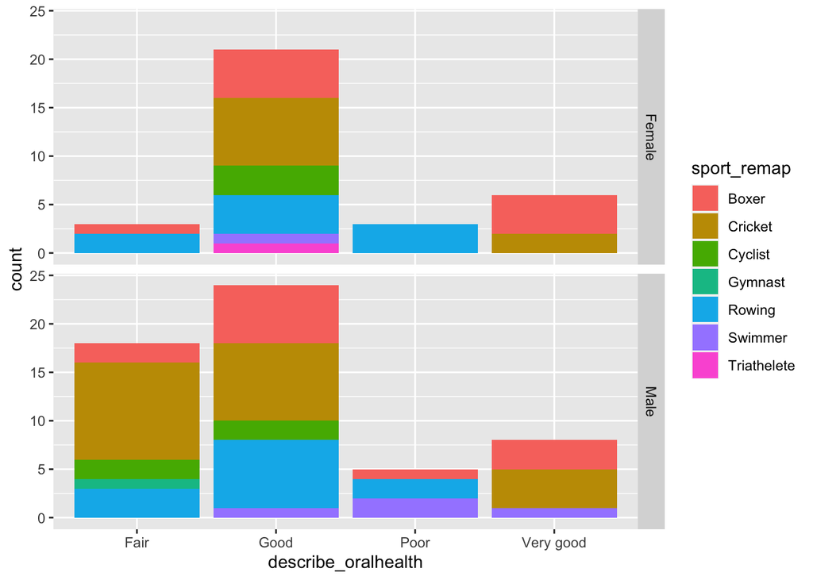

```r
ggplot(rawSelection2) +
  geom_bar(aes(x=describe_oralhealth, fill=sport_remap))  +
  facet_grid(gender~.)
```

```r
# names(rawSelection2)
is.factor('describe_oralheath')
```

```
## [1] FALSE
```

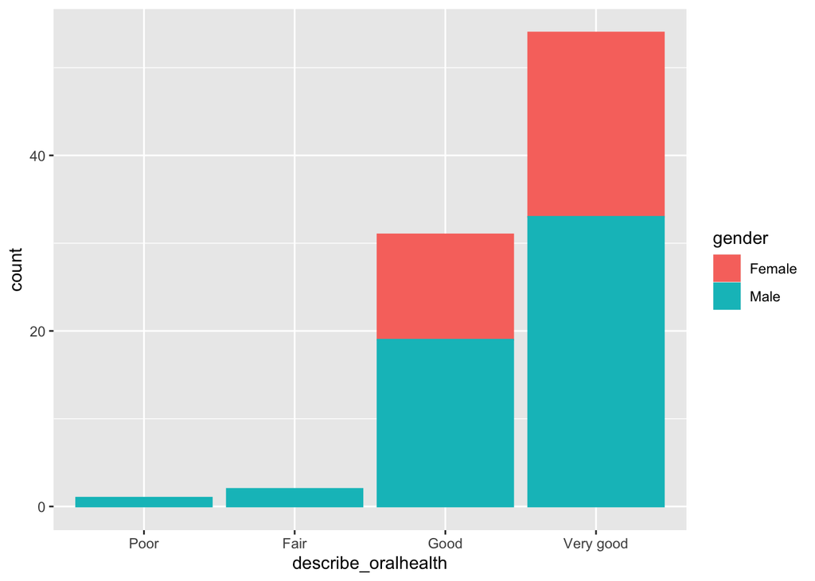

```r
p <- rawSelection2 %>%
  mutate(describe_oralhealth = as.factor(describe_health)) %>%
  mutate(describe_oralhealth = fct_relevel(describe_oralhealth,
                                           c("Poor",
                                             "Fair",
                                             "Good",
                                             "Very good")
                                           )) %>%
  ggplot() +
  geom_bar(aes(x= describe_oralhealth, col=gender, fill=gender))

p
```

```r
rawSelection2 %>% select(last_dental_visit)
```

```
## # A tibble: 88 × 1
##    last_dental_visit
##    <chr>
##  1 More than 2 years ago
##  2 Within the past 6 months
##  3 1-2 years ago
##  4 6-12 months ago
##  5 Within the past 6 months
##  6 6-12 months ago
##  7 1-2 years ago
##  8 Within the past 6 months
##  9 Within the past 6 months
## 10 6-12 months ago
## # ℹ 78 more rows
```

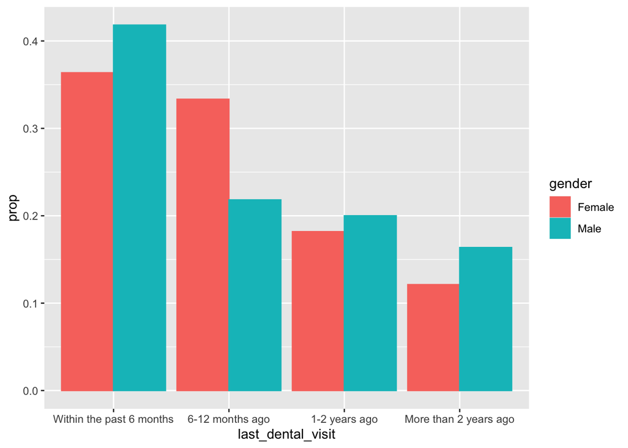

```r
p <- rawSelection2 %>%
  mutate(last_dental_visit=as_factor(last_dental_visit)) |>
  mutate(last_dental_visit=fct_relevel(last_dental_visit,
                                       c("Within the past 6 months",
                                         "6-12 months ago",
                                         "1-2 years ago",
                                         "More than 2 years ago")
                                       )) |>
  ggplot() +
  geom_bar(aes(x=last_dental_visit, y= ..prop.., col=gender, fill=gender, group=gender),
           position=position_dodge(), stat = "count")

p
```

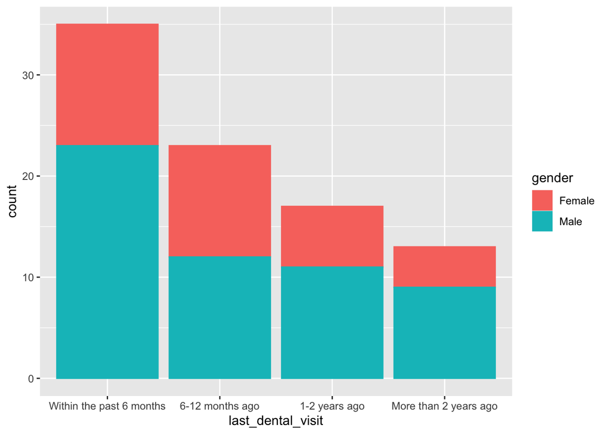

```r
p <- rawSelection2 %>%
  mutate(last_dental_visit=as_factor(last_dental_visit)) |>
  mutate(last_dental_visit=fct_relevel(last_dental_visit,
                                       c("Within the past 6 months",
                                         "6-12 months ago",
                                         "1-2 years ago",
                                         "More than 2 years ago")
                                       )) |>
  ggplot() +
  geom_bar(aes(x=last_dental_visit, col=gender, fill=gender))

p
```

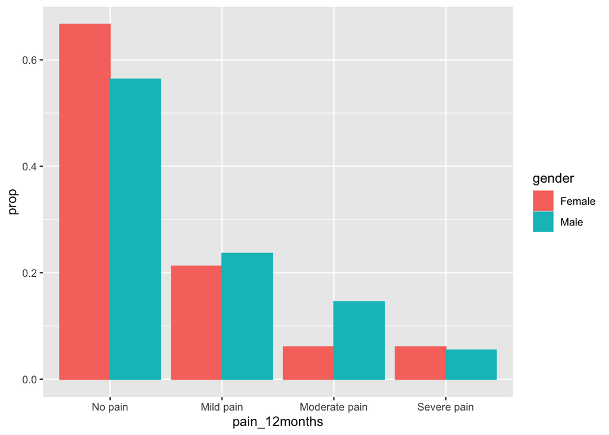

```r
p <- rawSelection2 %>%
  mutate(pain_12months=as_factor(pain_12months)) |>
  mutate(pain_12months=fct_relevel(pain_12months,
                                       c("No pain",
                                         "Mild pain",
                                         "Moderate pain",
                                         "Severe pain")
                                       )) |>
  ggplot() +
  geom_bar(aes(x=pain_12months, y= ..prop.., col=gender, fill=gender, group=gender),
           position=position_dodge(), stat = "count")

p
```

# Creat T1 descr vars by gender and total

ethnicity, Education level, SPort, Occupation?

```r
Table_1_variables <- rawSelection2 |>
  select(gender,ethnicity) |>
  mutate(
    ethnicity = recode_factor(ethnicity,
      "Irish White" = "Irish White",
      "Northern Irish/English/Welsh/Scotish" = "Northern Irish/English/Welsh/Scotish",
      .default = "Other"
    )
  ) |>
  group_by(gender, ethnicity) |>
  reframe(n = n())  |>
  group_by(gender) |>
  mutate(percentage = n/sum(n)*100)

knitr::kable(Table_1_variables, digits = 2)
```

| gender | ethnicity | n | percentage |
| --- | --- | --- | --- |
| Female | Irish White | 32 | 96.97 |
| Female | Northern Irish/English/Welsh/Scotish | 1 | 3.03 |
| Male | Irish White | 36 | 65.45 |
| Male | Northern Irish/English/Welsh/Scotish | 10 | 18.18 |
| Male | Other | 9 | 16.36 |

```r
Table_2_variables <- rawSelection2 |>
select(gender, level_education) |>
  mutate(
    level_of_education =
      recode_factor(
        level_education,
        "University undergraduate degree" = "University degree",
        "University postgraduate degree" = "University degree",
        "FE College (or equivalent)" = "FE College",
        "Leaving Certificate" = "Junior or Leaving Certificate",
        "Junior Certificate" = "Junior or Leaving Certificate"
      )

  ) |>
  group_by(gender, level_education) |>
  reframe(n = n()) |>
  group_by(gender) |>
  mutate(percentage = (n / sum(n)) * 100)


knitr::kable(Table_2_variables, digits = 2)
```

| gender | level_education | n | percentage |
| --- | --- | --- | --- |
| Female | FE College (or equivalent) | 7 | 21.21 |
| Female | Leaving Certificate | 9 | 27.27 |
| Female | University postgraduate degree | 4 | 12.12 |
| Female | University undergraduate degree | 13 | 39.39 |
| Male | FE College (or equivalent) | 10 | 18.18 |
| Male | Junior Certificate | 3 | 5.45 |
| Male | Leaving Certificate | 17 | 30.91 |
| Male | University postgraduate degree | 2 | 3.64 |
| Male | University undergraduate degree | 23 | 41.82 |

which column? AH? STUDENT???

```r
Table_3_variables <- rawSelection2 |>
  select(gender,occupation) |>
  mutate(
    occupation = recode_factor(occupation,
      "Semi-skilled / unskilled manual" = "Employed",
      "Professional managers" = "Employed", "Other non manual / skilled manual" = "Employed", "All other gainfully occupied and unknown" = "Unemployed/Full-time athlete"
    )
  ) |>
  group_by(gender, occupation) |>
  reframe(n = n())  |>
  group_by(gender) |>
  mutate(percentage = n/sum(n)*100)

knitr::kable(Table_3_variables, digits = 2)
```

| gender | occupation | n | percentage |
| --- | --- | --- | --- |
| Female | Employed | 8 | 24.24 |
| Female | Unemployed/Full-time athlete | 25 | 75.76 |
| Male | Employed | 11 | 20.00 |
| Male | Unemployed/Full-time athlete | 44 | 80.00 |

# Recoded levels for exact occupation T1

```r
Table_occup_variables <- rawSelection2 %>%
  mutate(exact_occupation_recoded = case_when(
    exact_occupation %in% c(
      "Unemployed",
      "Athlete",
      "Cricket",
      "Nil",
      "Not working",
      "NoIl student",
      "No",
      "Student",
      "Athlete/learning and development pwc",
      "None",
      "Studen",
      "Athlete/student",
      "Student athlete",
      "Athlete / student",
      "Athlete and student"
    ) ~ "full time athlete",
    TRUE ~ "other"
  )) %>%
  group_by(gender, exact_occupation_recoded) %>%
  summarize(n = n()) %>%
  mutate(percentage = n / sum(n) * 100)
knitr::kable(Table_occup_variables, digits = 2)
```

| gender | exact_occupation_recoded | n | percentage |
| --- | --- | --- | --- |
| Female | full time athlete | 26 | 78.79 |
| Female | other | 7 | 21.21 |
| Male | full time athlete | 40 | 72.73 |
| Male | other | 15 | 27.27 |

```r
Table_4_variables <- rawSelection2 |>
select(gender, sport_remap) |>
  group_by(gender, sport_remap) |>
  reframe(n = n()) |>
  group_by(gender) |>
  mutate(percentage = (n / sum(n)) * 100)


knitr::kable(Table_4_variables, digits = 2)
```

| gender | sport_remap | n | percentage |
| --- | --- | --- | --- |
| Female | Boxer | 10 | 30.30 |
| Female | Cricket | 9 | 27.27 |
| Female | Cyclist | 3 | 9.09 |
| Female | Rowing | 9 | 27.27 |
| Female | Swimmer | 1 | 3.03 |
| Female | Triathelete | 1 | 3.03 |
| Male | Boxer | 12 | 21.82 |
| Male | Cricket | 22 | 40.00 |
| Male | Cyclist | 4 | 7.27 |
| Male | Gymnast | 1 | 1.82 |
| Male | Rowing | 12 | 21.82 |
| Male | Swimmer | 4 | 7.27 |

```r
Table_5_variables <- rawSelection2 |>
  select(gender,age) |>
  mutate(
    age = cut(age,
      breaks = c(19,25,30,60),
      include.lowest = T,
      right = F)
  ) |>
  group_by(gender, age) |>
  reframe(n = n())  |>
  group_by(gender) |>
  mutate(percentage = n/sum(n)*100)

knitr::kable(Table_5_variables, digits = 2)
```

| gender | age | n | percentage |
| --- | --- | --- | --- |
| Female | [19,25) | 18 | 54.55 |
| Female | [25,30) | 9 | 27.27 |
| Female | [30,60] | 6 | 18.18 |
| Male | [19,25) | 26 | 47.27 |
| Male | [25,30) | 19 | 34.55 |
| Male | [30,60] | 10 | 18.18 |

# demographics on Eircode??

DO A TABLE 5

# ICDAS SCORE 1 Analysis

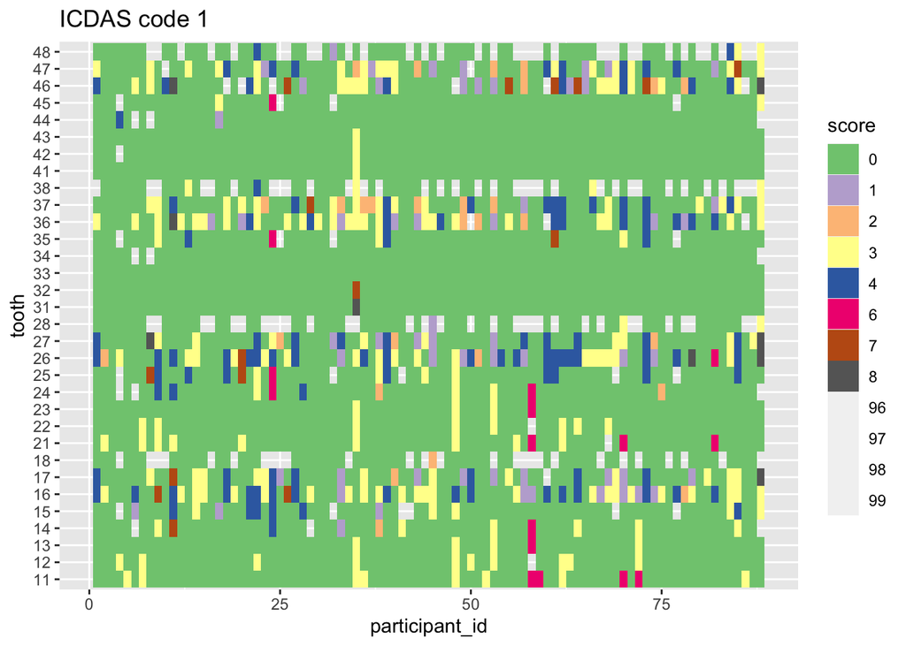

```r
icdasScore <- rawSelection2 %>%
  select(starts_with("icdas_score_1"), "participant_id") %>%
  filter(!is.na(participant_id)) %>%
    pivot_longer(
    cols = starts_with("icdas_sco"),
    names_to = "tooth",
    values_to = "score"
  ) |>
  mutate(
    tooth = str_replace(tooth, "icdas_score_1_", ""),
    score = as.factor(score),
    participant_id = as.numeric(as.factor(participant_id))
  )

#
ggplot(icdasScore, aes(x = participant_id, y = tooth, fill = score)) +
  geom_tile() +
 scale_fill_discrete() +
 ggtitle("ICDAS code 1") +
 scale_fill_brewer(palette = "Accent")
```

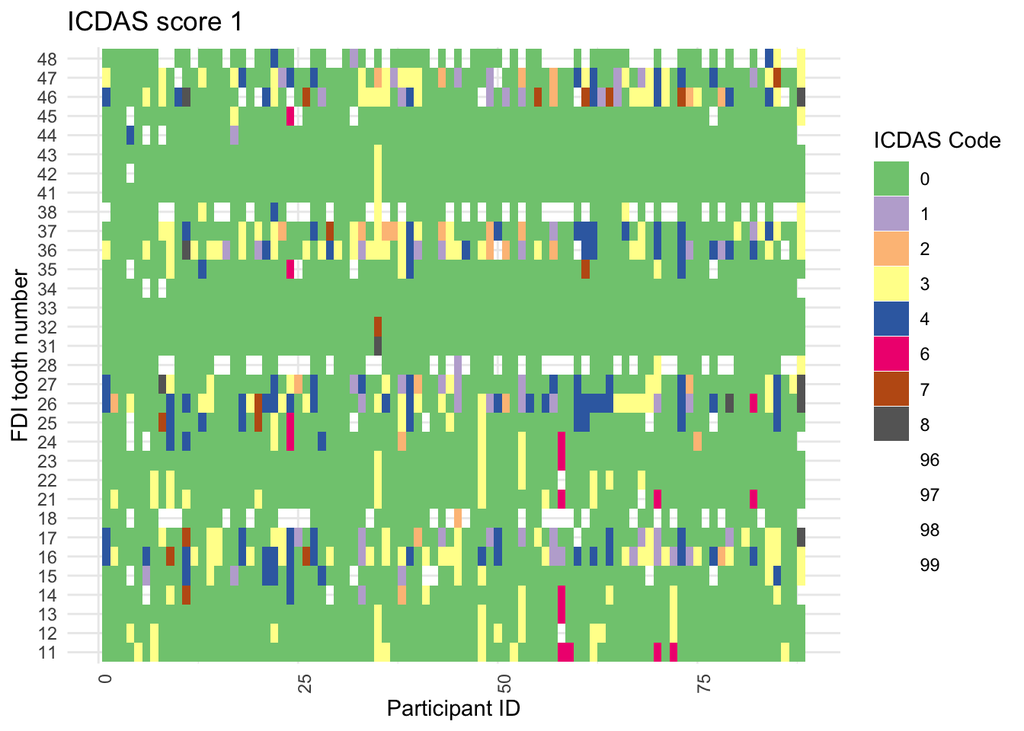

```r
# change score to code without affect values in map to align with paper 2 definitions and prev paper

icdasScore <- rawSelection2 %>%
  select(starts_with("icdas_score_1"), "participant_id") %>%
  filter(!is.na(participant_id)) %>%
    pivot_longer(
    cols = starts_with("icdas_sco"),
    names_to = "FDI_tooth_number",  # Changed from "tooth" to "FDI_tooth_number"
    values_to = "code"  # Changed from "score" to "code" as per previous suggestion
  ) |>
  mutate(
    FDI_tooth_number = str_replace(FDI_tooth_number, "icdas_score_1_", ""),  # Changed variable name
    code = as.factor(code),
    participant_id = as.numeric(as.factor(participant_id))
  )

ggplot(icdasScore, aes(x = participant_id, y = FDI_tooth_number, fill = code)) +
  geom_tile() +
  scale_fill_brewer(palette = "Accent") +
  ggtitle("ICDAS score 1") +
  labs(
    fill = "ICDAS Code",
    x = "Participant ID",
    y = "FDI tooth number"  # Changed y-axis label
  ) +
  theme_minimal() +
  theme(axis.text.x = element_text(angle = 90, hjust = 1))
```

T1 summ by gender count ICDAS 1 Note these are with previous defintinos of score and code not updated like the previous heat map

```r
icdasScore1Table <- rawSelection2 %>%
  select(starts_with("icdas_score_1"), participant_id, gender) %>%
  filter(!is.na(participant_id)) %>%
  pivot_longer(
    cols = starts_with("icdas_sco"),
    names_to = "tooth",
    values_to = "score"
  ) |>
  mutate(
    tooth = str_replace(tooth, "icdas_score_1_", ""),
    score = factor(score)
  ) |>
  group_by(gender, score) |>
  reframe(countTeeth = n(),
          countSubject = n_distinct(participant_id)
          ) |>
  group_by(gender) |>
  mutate(pcTeeth = countTeeth / sum(countTeeth) *100,
         pcSubject = countSubject / sum(countSubject)* 100
         )

knitr::kable(icdasScore1Table, caption = "Number of subject at given icdas score 1", digits=2)
```

Number of subject at given icdas score 1

| gender | score | countTeeth | countSubject | pcTeeth | pcSubject |
| --- | --- | --- | --- | --- | --- |
| Female | 0 | 798 | 33 | 75.57 | 25.00 |
| Female | 1 | 19 | 12 | 1.80 | 9.09 |
| Female | 2 | 14 | 9 | 1.33 | 6.82 |
| Female | 3 | 94 | 24 | 8.90 | 18.18 |
| Female | 4 | 44 | 12 | 4.17 | 9.09 |
| Female | 6 | 1 | 1 | 0.09 | 0.76 |
| Female | 7 | 7 | 6 | 0.66 | 4.55 |
| Female | 8 | 6 | 3 | 0.57 | 2.27 |
| Female | 96 | 5 | 4 | 0.47 | 3.03 |
| Female | 97 | 5 | 4 | 0.47 | 3.03 |
| Female | 98 | 31 | 11 | 2.94 | 8.33 |
| Female | 99 | 32 | 13 | 3.03 | 9.85 |
| Male | 0 | 1392 | 55 | 79.09 | 27.64 |
| Male | 1 | 40 | 17 | 2.27 | 8.54 |
| Male | 2 | 14 | 9 | 0.80 | 4.52 |
| Male | 3 | 113 | 40 | 6.42 | 20.10 |
| Male | 4 | 74 | 24 | 4.20 | 12.06 |
| Male | 6 | 15 | 5 | 0.85 | 2.51 |
| Male | 7 | 9 | 6 | 0.51 | 3.02 |
| Male | 8 | 3 | 2 | 0.17 | 1.01 |
| Male | 96 | 5 | 4 | 0.28 | 2.01 |
| Male | 97 | 9 | 6 | 0.51 | 3.02 |
| Male | 98 | 41 | 14 | 2.33 | 7.04 |
| Male | 99 | 45 | 17 | 2.56 | 8.54 |

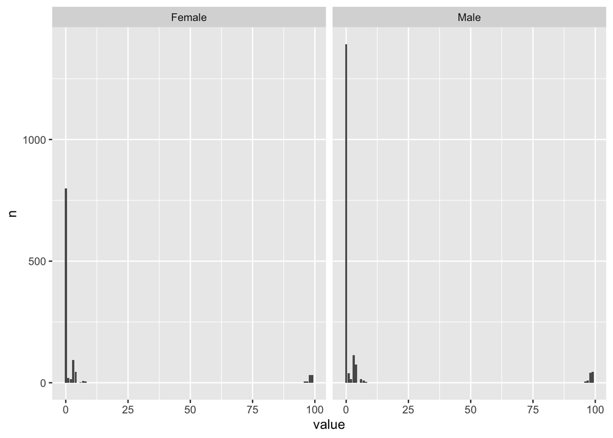

```r
icdasScore1 <- rawSelection2 %>% select(starts_with("icdas_score_1"), "participant_id", gender) %>% filter(! is.na(participant_id)) %>% filter(! is.na(participant_id)) %>%
  pivot_longer(cols = starts_with("icdas_sco")) %>%
  group_by(participant_id, gender, value) %>%
  count()

# todo cross check the geom_bar
ggplot(icdasScore1) + geom_bar(aes(x=value, y=n), stat = "identity") +
facet_wrap(gender~.,scales="free_x", ncol = 2)
```

Below the cumulative scores

# What we want is to group 0-2 (sound or F/S) and 3-4 (fills) and total for 97, 98 sep

```r
cumulativeIcdas1 <- icdasScore1 %>% group_by(value) %>% summarise(n=sum(n)) %>% mutate(csum=cumsum(n)/sum(n)*100, pc=n/sum(n)*100)

knitr::kable(cumulativeIcdas1)
```

| value | n | csum | pc |
| --- | --- | --- | --- |
| 0 | 2190 | 77.76989 | 77.7698864 |
| 1 | 59 | 79.86506 | 2.0951705 |
| 2 | 28 | 80.85938 | 0.9943182 |
| 3 | 207 | 88.21023 | 7.3508523 |
| 4 | 118 | 92.40057 | 4.1903409 |
| 6 | 16 | 92.96875 | 0.5681818 |
| 7 | 16 | 93.53693 | 0.5681818 |
| 8 | 9 | 93.85653 | 0.3196023 |
| 96 | 10 | 94.21165 | 0.3551136 |
| 97 | 14 | 94.70881 | 0.4971591 |
| 98 | 72 | 97.26562 | 2.5568182 |
| 99 | 77 | 100.00000 | 2.7343750 |

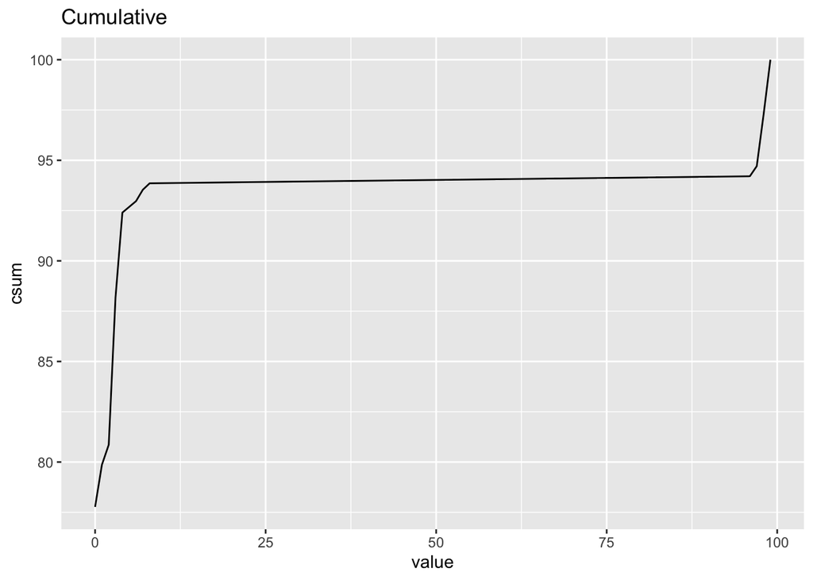

```r
ggplot(cumulativeIcdas1) + geom_line(aes(x=value, y=csum)) + ggtitle("Cumulative")
```

Cut off for the score

```r
sumCutOff <- function(value, n, cutoff){
  sum(n[value >= cutoff & value < 90])
}



teethCutoffScore1 <- icdasScore1 %>% group_by(value) %>% summarise(n=sum(n)) %>%
summarise(cutoff_1=sumCutOff(value, n, 1)/sum(n)*100,
          cutoff_2=sumCutOff(value, n, 2)/sum(n)*100,
          cutoff_3=sumCutOff(value, n, 3)/sum(n)*100,
          cutoff_4=sumCutOff(value, n, 4)/sum(n)*100,
          cutoff_5=sumCutOff(value, n, 5)/sum(n)*100
          )

knitr::kable(teethCutoffScore1, caption = "ICIDAS score 1 cutoff value above equal ")
```

ICIDAS score 1 cutoff value above equal

| cutoff_1 | cutoff_2 | cutoff_3 | cutoff_4 | cutoff_5 |
| --- | --- | --- | --- | --- |
| 16.08665 | 13.99148 | 12.99716 | 5.646307 | 1.455966 |

```r
uniqueCutOff <- function(value, subject, cutoff){
  length(
    unique(
      subject[value >= cutoff & value < 90]
    )
  )
}

participantCutoffScore1 <- tibble(
c1=uniqueCutOff(icdasScore1$value, icdasScore1$participant_id, 1),
c2=uniqueCutOff(icdasScore1$value, icdasScore1$participant_id, 2),
c3=uniqueCutOff(icdasScore1$value, icdasScore1$participant_id, 3),
c4=uniqueCutOff(icdasScore1$value, icdasScore1$participant_id, 4),
)

knitr::kable(participantCutoffScore1, caption = "ICIDAS score 1 cutoff value above equal - unique subjects ")
```

ICIDAS score 1 cutoff value above equal - unique subjects

| c1 | c2 | c3 | c4 |
| --- | --- | --- | --- |
| 83 | 82 | 76 | 45 |

# ICDAS SCORE 2 Analysis

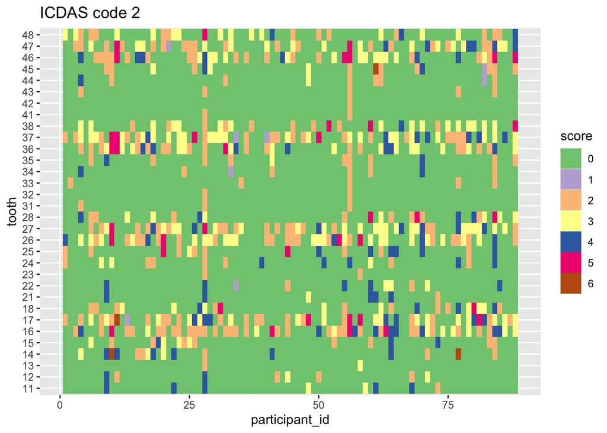

```r
icdasScore2 <- rawSelection2 %>%
  select(starts_with("icdas_score_2"), "participant_id") %>%
  filter(!is.na(participant_id)) %>%
    pivot_longer(
    cols = starts_with("icdas_sco"),
    names_to = "tooth",
    values_to = "score"
  ) |>
  mutate(
    tooth = str_replace(tooth, "icdas_score_2_", ""),
    score = as.factor(score),
    participant_id = as.numeric(as.factor(participant_id))
  )

#
ggplot(icdasScore2, aes(x = participant_id, y = tooth, fill = score)) +
  geom_tile() +
 ggtitle("ICDAS code 2") +
 scale_fill_brewer(palette = "Accent")
```

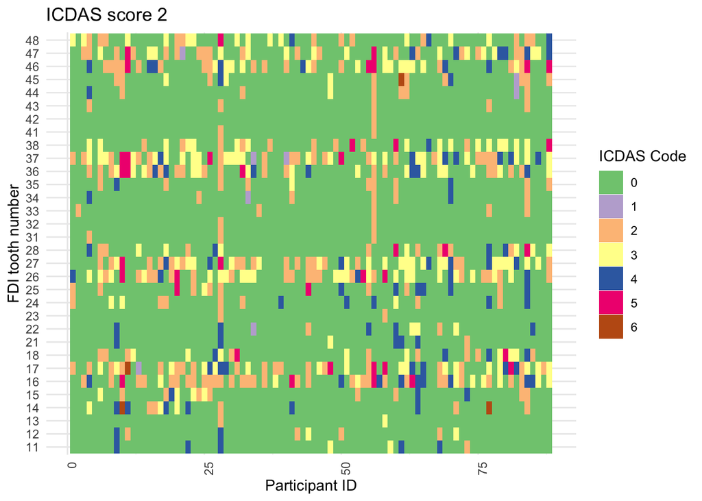

```r
# similar to ICDAS 1 earlier -change 'score' to 'code' without affect values in map to align with paper 2 definitions and prev paper

icdasScore <- rawSelection2 %>%
  select(starts_with("icdas_score_2"), "participant_id") %>%
  filter(!is.na(participant_id)) %>%
    pivot_longer(
    cols = starts_with("icdas_sco"),
    names_to = "FDI_tooth_number",  # Changed from "tooth" to "FDI_tooth_number"
    values_to = "code"  # Changed from "score" to "code" as per previous suggestion
  ) |>
  mutate(
    FDI_tooth_number = str_replace(FDI_tooth_number, "icdas_score_2_", ""),  # Changed variable name
    code = as.factor(code),
    participant_id = as.numeric(as.factor(participant_id))
  )

ggplot(icdasScore, aes(x = participant_id, y = FDI_tooth_number, fill = code)) +
  geom_tile() +
  scale_fill_brewer(palette = "Accent") +
  ggtitle("ICDAS score 2") +
  labs(
    fill = "ICDAS Code",
    x = "Participant ID",
    y = "FDI tooth number"  # Changed y-axis label
  ) +
  theme_minimal() +
  theme(axis.text.x = element_text(angle = 90, hjust = 1))
```

```r
icdasScore2Table <- rawSelection2 %>%
  select(starts_with("icdas_score_2"), participant_id, gender) %>%
  filter(!is.na(participant_id)) %>%
  pivot_longer(
    cols = starts_with("icdas_sco"),
    names_to = "tooth",
    values_to = "score"
  ) |>
  mutate(
    tooth = str_replace(tooth, "icdas_score_2_", ""),
    score = factor(score)
  ) |>
  group_by(gender, score) |>
  reframe(countTeeth = n(),
          countSubject = n_distinct(participant_id)
          ) |>
  group_by(gender) |>
  mutate(pcTeeth = countTeeth / sum(countTeeth) *100,
         pcSubject = countSubject / sum(countSubject)* 100
         )

knitr::kable(icdasScore2Table, caption = "Number of subject at given icdas score 2", digits=2)
```

Number of subject at given icdas score 2

| gender | score | countTeeth | countSubject | pcTeeth | pcSubject |
| --- | --- | --- | --- | --- | --- |
| Female | 0 | 817 | 33 | 77.37 | 29.46 |
| Female | 1 | 1 | 1 | 0.09 | 0.89 |
| Female | 2 | 110 | 30 | 10.42 | 26.79 |
| Female | 3 | 84 | 26 | 7.95 | 23.21 |
| Female | 4 | 34 | 15 | 3.22 | 13.39 |
| Female | 5 | 10 | 7 | 0.95 | 6.25 |
| Male | 0 | 1352 | 55 | 76.82 | 26.96 |
| Male | 1 | 7 | 5 | 0.40 | 2.45 |
| Male | 2 | 169 | 46 | 9.60 | 22.55 |
| Male | 3 | 122 | 48 | 6.93 | 23.53 |
| Male | 4 | 77 | 30 | 4.38 | 14.71 |
| Male | 5 | 29 | 16 | 1.65 | 7.84 |
| Male | 6 | 4 | 4 | 0.23 | 1.96 |

```r
icdasScoreGender <- rawSelection2 %>% select(starts_with("icdas_score_2"), "participant_id", gender) %>% filter(! is.na(participant_id)) %>%
  pivot_longer(cols = starts_with("icdas_sco"))

icdasScoreGender$id <-as.numeric(as.factor(icdasScoreGender$participant_id))
icdasScoreGender$score_id <-as.numeric(as.factor(icdasScoreGender$name))
```

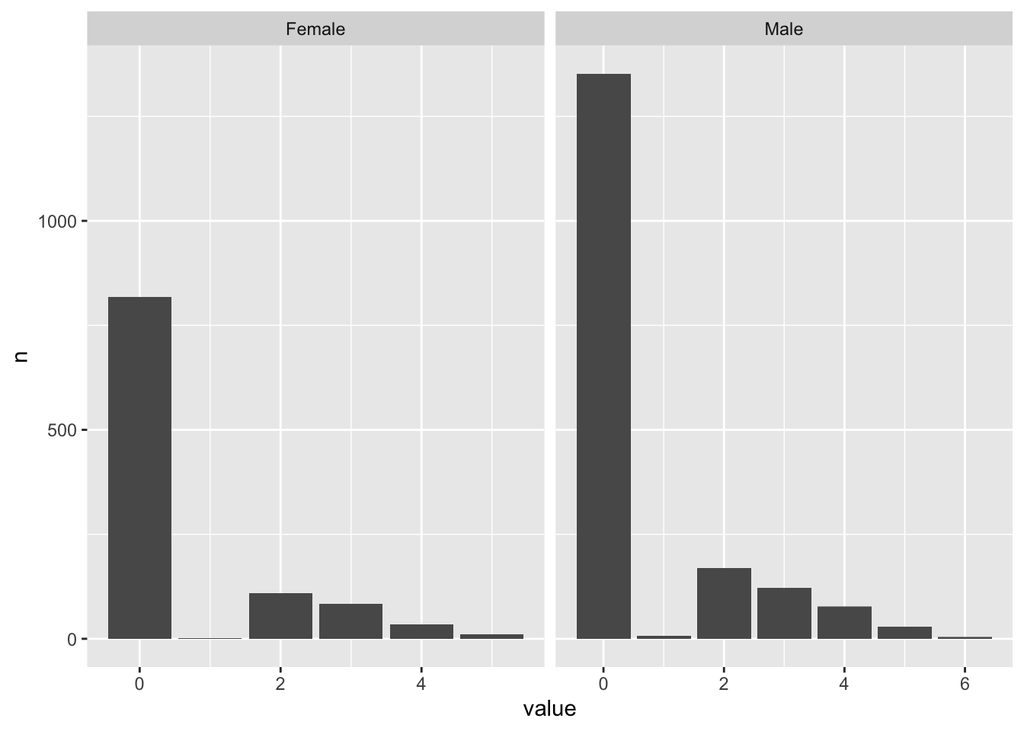

```r
icdasScore2 <- rawSelection2 %>% select(starts_with("icdas_score_2"), "participant_id", gender) %>% filter(! is.na(participant_id)) %>% filter(! is.na(participant_id)) %>%
  pivot_longer(cols = starts_with("icdas_sco")) %>%
  group_by(participant_id, gender, value) %>%
  count()

# todo cross check the geom_bar
ggplot(icdasScore2) + geom_bar(aes(x=value, y=n), stat = "identity") +
facet_wrap(gender~.,scales="free_x", ncol = 2)
```

```r
icdasScore2 %>% group_by(gender, value) %>% summarise(n=sum(n), distinct_subject=n_distinct(participant_id))
```

```
## # A tibble: 13 × 4
## # Groups:   gender [2]
##    gender value     n distinct_subject
##    <chr>  <dbl> <int>            <int>
##  1 Female     0   817               33
##  2 Female     1     1                1
##  3 Female     2   110               30
##  4 Female     3    84               26
##  5 Female     4    34               15
##  6 Female     5    10                7
##  7 Male       0  1352               55
##  8 Male       1     7                5
##  9 Male       2   169               46
## 10 Male       3   122               48
## 11 Male       4    77               30
## 12 Male       5    29               16
## 13 Male       6     4                4
```

```r
cumulativeIcdas2 <- icdasScore2 %>% group_by(value) %>% summarise(n=sum(n)) %>% mutate(csum=cumsum(n)/sum(n)*100, pc=n/sum(n)*100)

knitr::kable(cumulativeIcdas2)
```

| value | n | csum | pc |
| --- | --- | --- | --- |
| 0 | 2169 | 77.02415 | 77.0241477 |
| 1 | 8 | 77.30824 | 0.2840909 |
| 2 | 279 | 87.21591 | 9.9076705 |
| 3 | 206 | 94.53125 | 7.3153409 |
| 4 | 111 | 98.47301 | 3.9417614 |
| 5 | 39 | 99.85795 | 1.3849432 |
| 6 | 4 | 100.00000 | 0.1420455 |

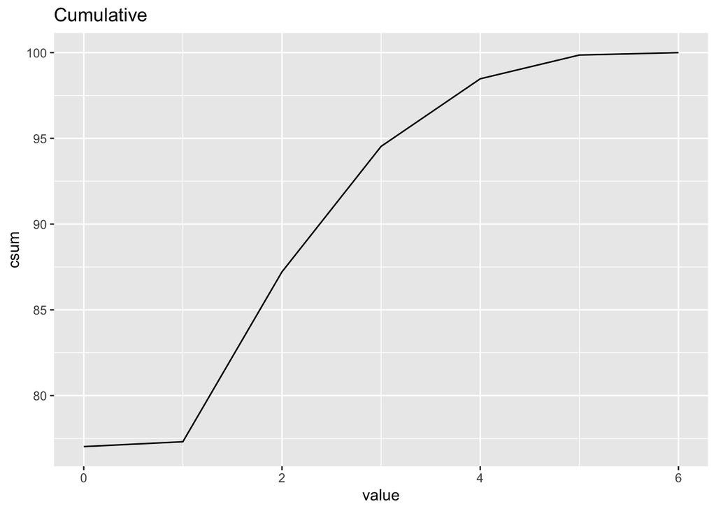

```r
ggplot(cumulativeIcdas2) + geom_line(aes(x=value, y=csum)) + ggtitle("Cumulative")
```

```r
sumCutOff <- function(value, n, cutoff){
  sum(n[value >= cutoff])
}



teethCutoff <- icdasScore2 %>% group_by(value) %>% summarise(n=sum(n)) %>%
summarise(cutoff_1=sumCutOff(value, n, 1)/sum(n)*100,
          cutoff_2=sumCutOff(value, n, 2)/sum(n)*100,
          cutoff_3=sumCutOff(value, n, 3)/sum(n)*100,
          cutoff_4=sumCutOff(value, n, 4)/sum(n)*100,
          cutoff_5=sumCutOff(value, n, 5)/sum(n)*100
          )

knitr::kable(teethCutoff, caption = "ICIDAS Score 2 % of number of teeth above or equal at a cutoff")
```

ICIDAS Score 2 % of number of teeth above or equal at a cutoff

| cutoff_1 | cutoff_2 | cutoff_3 | cutoff_4 | cutoff_5 |
| --- | --- | --- | --- | --- |
| 22.97585 | 22.69176 | 12.78409 | 5.46875 | 1.526989 |

```r
uniqueCutOff <- function(value, subject, cutoff){
  length(
    unique(
      subject[value >= cutoff]
    )
  )
}

participantCutoff <- tibble(
c1=uniqueCutOff(icdasScore2$value, icdasScore2$participant_id, 1),
c2=uniqueCutOff(icdasScore2$value, icdasScore2$participant_id, 2),
c3=uniqueCutOff(icdasScore2$value, icdasScore2$participant_id, 3),
c4=uniqueCutOff(icdasScore2$value, icdasScore2$participant_id, 4),
)

knitr::kable(participantCutoff, caption = "ICIDAS Score 2  number of subjects above or equal at a cutoff")
```

ICIDAS Score 2 number of subjects above or equal at a cutoff

| c1 | c2 | c3 | c4 |
| --- | --- | --- | --- |
| 87 | 87 | 79 | 53 |

# BPE Analysis

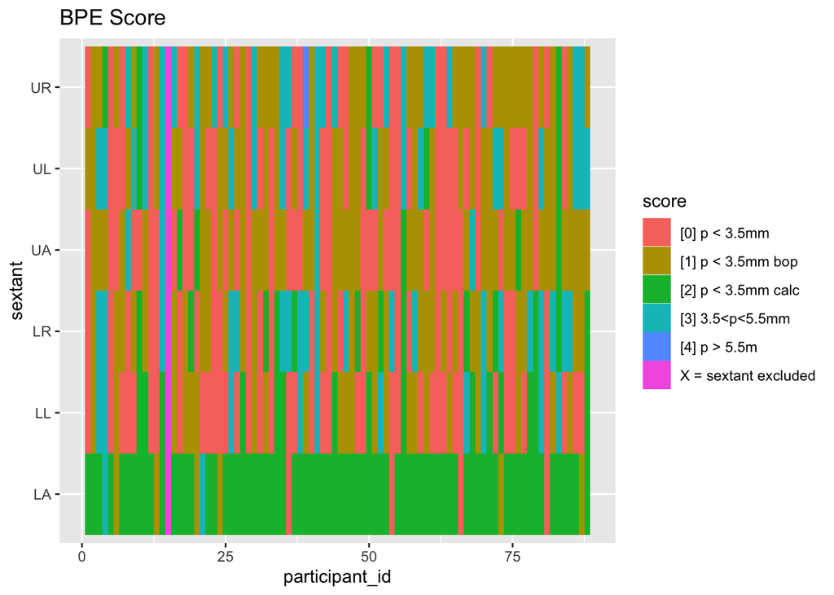

```r
bpeScore <- rawSelection2 %>%
  select(starts_with("BPE_"), "participant_id") %>%
  filter(!is.na(participant_id)) %>%
    pivot_longer(
    cols = starts_with("BPE_"),
    names_to = "sextant",
    values_to = "score"
  ) |>
  mutate(
    sextant = str_replace(sextant, "BPE_", ""),
    score = as.factor(score),
    participant_id = as.numeric(as.factor(participant_id))
  )

#
ggplot(bpeScore, aes(x = participant_id, y = sextant, fill = score)) +
  geom_tile() +
 scale_fill_discrete() +
 ggtitle("BPE Score")
```

```r
bpeTable <- rawSelection2 %>%
  select(starts_with("BPE_"), "participant_id", gender) %>%
  filter(!is.na(participant_id)) %>%
    pivot_longer(
    cols = starts_with("BPE_"),
    names_to = "sextant",
    values_to = "score"
  ) |>
  filter(score != 'X = sextant excluded')  |>
  group_by(
    participant_id, gender
  ) |>
  reframe(
    score = max(score)
  ) |>
  mutate(
    participant_id = as.numeric(as.factor(participant_id))
  ) |>
  group_by(gender, score) |>
  reframe(countSubject = n_distinct(participant_id)
          ) |>
  group_by(gender) |>
  mutate(pcSubject = countSubject / sum(countSubject)* 100
         )

knitr::kable(bpeTable, caption = "Number of subject at given bpe score", digits=2)
```

Number of subject at given bpe score

| gender | score | countSubject | pcSubject |
| --- | --- | --- | --- |
| Female | [1] p < 3.5mm bop | 1 | 3.12 |
| Female | [2] p < 3.5mm calc | 15 | 46.88 |
| Female | [3] 3.5<p<5.5mm | 16 | 50.00 |
| Male | [1] p < 3.5mm bop | 4 | 7.27 |
| Male | [2] p < 3.5mm calc | 21 | 38.18 |
| Male | [3] 3.5<p<5.5mm | 29 | 52.73 |
| Male | [4] p > 5.5m | 1 | 1.82 |

# BEWE Analysis

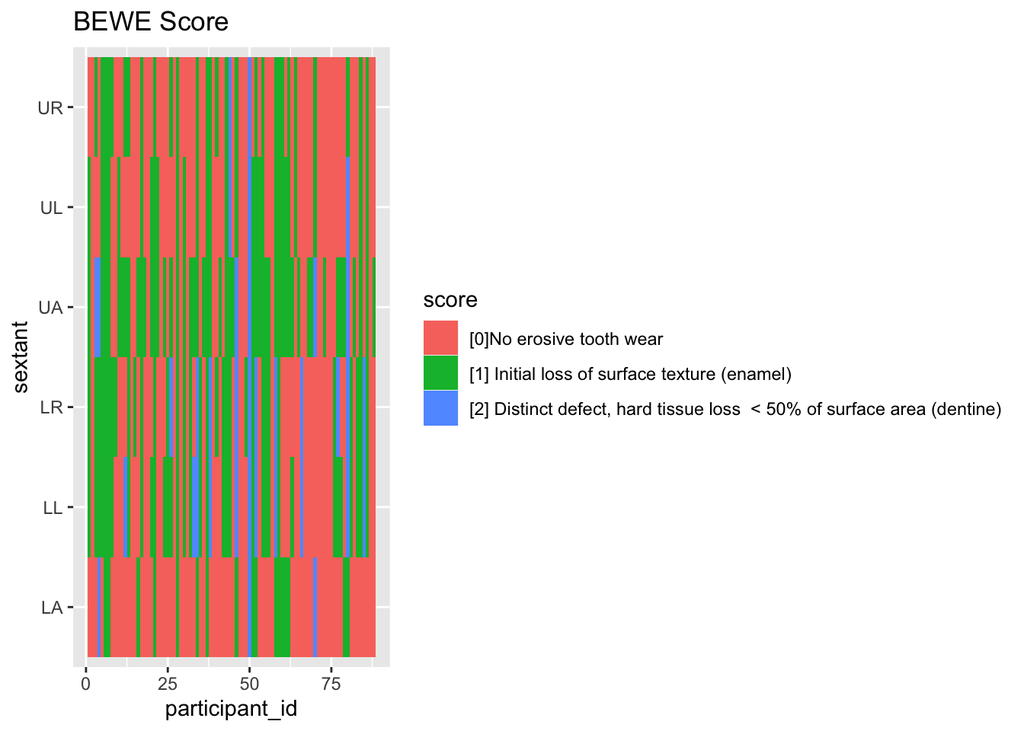

```r
beweScore <- rawSelection2 %>%
  select(starts_with("BEWE_"), "participant_id") %>%
  filter(!is.na(participant_id)) %>%
    pivot_longer(
    cols = starts_with("BEWE_"),
    names_to = "sextant",
    values_to = "score"
  ) |>
  mutate(
    sextant = str_replace(sextant, "BEWE_", ""),
    score = as.factor(score),
    participant_id = as.numeric(as.factor(participant_id))
  )

#
ggplot(beweScore, aes(x = participant_id, y = sextant, fill = score)) +
  geom_tile() +
 scale_fill_discrete() +
 ggtitle("BEWE Score")
```

```r
beweTable <- rawSelection2 %>%
  select(starts_with("BEWE_"), "participant_id", gender) %>%
  filter(!is.na(participant_id)) %>%
    pivot_longer(
    cols = starts_with("BEWE_"),
    names_to = "sextant",
    values_to = "score"
  ) |>
  group_by(
    participant_id, gender
  ) |>
  reframe(
    score = sum(as.numeric(str_extract(score, "[0-4]")))
  ) |>
  mutate(
    participant_id = as.numeric(as.factor(participant_id))
  ) |>
  group_by(gender, score) |>
  reframe(countSubject = n_distinct(participant_id)
          ) |>
  group_by(gender) |>
  mutate(pcSubject = countSubject / sum(countSubject)* 100
         )

knitr::kable(beweTable, caption = "Number of subject at given and their BEWE total score", digits=2)
```

Number of subject at given and their BEWE total score

| gender | score | countSubject | pcSubject |
| --- | --- | --- | --- |
| Female | 0 | 10 | 30.30 |
| Female | 1 | 7 | 21.21 |
| Female | 2 | 7 | 21.21 |
| Female | 3 | 3 | 9.09 |
| Female | 4 | 1 | 3.03 |
| Female | 5 | 3 | 9.09 |
| Female | 6 | 1 | 3.03 |
| Female | 12 | 1 | 3.03 |
| Male | 0 | 7 | 12.73 |
| Male | 1 | 7 | 12.73 |
| Male | 2 | 9 | 16.36 |
| Male | 3 | 4 | 7.27 |
| Male | 4 | 8 | 14.55 |
| Male | 5 | 6 | 10.91 |
| Male | 6 | 7 | 12.73 |
| Male | 7 | 2 | 3.64 |
| Male | 8 | 3 | 5.45 |
| Male | 9 | 1 | 1.82 |
| Male | 10 | 1 | 1.82 |